# COR 142 Course Pack Notes

## Chapter 1

### Section 1.1. What Are Data?

- **Data** are observations that are recorded.
- **Statistics** is the science of collecting, organizing, summarizing, and analyzing data to questions and/or draw conclusions.
- We will focus on types of data and methods of collecting data.

### Why Do We Care About Statistics?

Statistics allows us to:

- Explore the world around us.
- Use evidence to check whether our beliefs are true.
- Find patterns which may lead to discoveries.
- Share new discoveries with others.

Keep in mind:

- Statistics must be used carefully.
- Inappropriate use will result in inaccurate beliefs.
- Results always contain a certain degree of uncertainty.

### Major Concepts in Statistics

1. **Variation:** Differences or changes in an item from others in the group.

**Example 1.1.1** Consider the figure below.

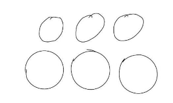

Which row has a greater variation of circles? The circles on the top row has greater variation.

2. **Data:**
- Observations gathered to draw conclusions.
- Context for data is essential.

**Example 1.1.2.** Consider the sequence of numbers: 10.12, 8.47, 9.34, 12.15. - This sequence of numbers could represent birth weights or shoe sizes. - Units matter!

### Data Analysis

- Data analysis is the process of examining collected data to look for patterns or numerical indicators that captures the essence of what the data is telling us.

## Section 1.2. Classifying And Storing Data Sources

- **Population:**
  - Collection of all data values that will ever occur for a group.
  - Often difficult (or impossible) to obtain all of the information.
- **Sample:**
  - A subset of the population.
  - Should represent the population at large.
  - Easier to (or can only) obtain information.

**Example 1.2.1.** Suppose you want to know what the predominant eye color in your country is. You survey a random sample of 2,500 people in your country, asking them about their eye color.

1. Who is the population? Every person in the country
2. Who is the sample? 2,500 people surveyed
3. What data was collected? The eye color of each person surveyed.

### Classifying Data

- **Variable:** Characteristics of data collected.
  - Types of variables: **categorical** and **numerical**
- **Categorical Variable:**
  1. Describes a quality or class.
  2. May be numbers, but cannot perform arithmetic operations.
  3. Examples: Eye colors, zip code, letter grades, SSN
- **Numerical Variable:**
  1. Describes a quantity or measurement.
  2. Example: temperature, height, weight, number of cars

**Example 1.2.2.** Classifying the following variables as numerical or categorical.

| **Variable** | **Numerical** | **Categorical** |
| --- | --- | --- |
| Height of a building | Yes | No |
| Letter grade on a set | No | Yes |
| Hours of sleep each night | Yes | No |
| Students’ GPAs | Yes | No |
| Type of cars | No | Yes |
| Vegetable varieties in a garden | No | Yes |
| Number of vegetable varieties | Yes | No |

### Sorting Data

**Coding Data:** Using numbers to record categorical data; may make reading the data easier.

| **Male** |
| --- |
| 1 |
| 0 |
| 0 |
| 1 |
| 1 |
| 0 |

**Stacked Data:**

- Data values are stored in a spreadsheet format.
- Each row contains data for a single observation.
- Can store many variables and observations.

**Example 1.2.4.** Each row in the table below is an observation of a dog at a local shelter.

| **Weight (lbs)** | **Gender** | **Illness** |
| --- | --- | --- |
| 10 | M | N |
| 27 | F | Y |
| 6 | F | N |
| 45 | M | N |
| 65 | M | N |
| 33 | F | Y |

- Variables: Weight, gender, and illness.
- How many dog are in the sample? 6 dogs

**Unstacked Data:**

- Data values are stored in two columns.
- Each column is a variable from a different group.
- Can only store data for two groups.
- Information in a row does not represent a single observation/individual.

**Example 1.2.5.** The table below represents the average number of sleep hours over a one-week period for a sample of men and women.

| **Men** | **Women** |
| --- | --- |
| 6.4 | 6.2 |
| 7.2 | 7.5 |
| 8.1 | 7.9 |
| 6.7 | 8.0 |
| 7.0 |  |
| 6.9 |  |

## Section 1.3. Organizing Categorical Data

### Why Do We Need to Organize Data?

- Raw data (data as it is collected) can be:
  - messy
  - hard to read and comprehend
  - difficult to see patterns
- Organizing data helps us to see patterns, but this is not always easy.

### Incomplete Data

**Example 1.3.1.** Given the data in the table below, which sport listed seems to be the most dangerous?

| **Sport** | **Number of Injuries** |
| --- | --- |
| Baseball | 165,842 |
| Basketball | 501,251 |
| Boxing | 20,878 |
| Football | 451,961 |
| Ice Hockey | 19,035 |
| Soccer | 208,214 |
| Softball | 121,175 |
| Tennis | 23,611 |
| Volleyball | 60,159 |

Based on the number of injuries, basketball seems to be the most dangerous sport to play. However, some factors are not considered in the table such as severity of injuries, the percentage of injuries over total number of players and/or games, etc.

### Comparing Data

When comparing data between different groups, it is often better to use **percentages** or **rates** for comparison.

**Example 1.3.2.** Given the sports data in the following more complete table, can we better answer which sport listed is the most dangerous?

| **Sport** | **Participants** | **Injuries** | **Rate of Injury/Participant** | **% of Participants Injured** | **Rate of Injury/1000 Participants** |
| --- | --- | --- | --- | --- | --- |
| Baseball | 11,500,000 | 165,842 | 0.01442 | 1.442 | 14.42 |
| Basketball | 24,400,00 | 501,251 | 0.02054 | 2.054 | 20.54 |
| Boxing | 45,000,000 | 20,878 | 0.00046 | 0.046 | 0.46 |
| Football | 8,900,000 | 451,961 | 0.05078 | 5.078 | 50.78 |
| Ice Hockey | 3,100,000 | 19,035 | 0.00614 | 0.614 | 6.14 |
| Soccer | 13,600,000 | 208,214 | 0.01531 | 1.531 | 15.31 |
| Softball | 11,800,000 | 121,175 | 0.01027 | 1.027 | 10.27 |
| Tennis | 10,800,000 | 23,611 | 0.00219 | 0.219 | 2.19 |
| Volleyball | 10,700,000 | 60,59 | 0.00562 | 0.562 | 5.62 |

Football has the highest rate of injury per participant, therefore, it is the most dangerous sport.

## Section 1.4. Collecting Data to Understand Causality Studying Causality

- Causality can be understood in terms of two variables:
  - **Treatment Variable:** Whether or not a specific treatment is used.
  - **Outcome/Response Variable:** Whether or not a certain outcome is observed.
  - *Goal:* To determine if the treatment variable causes a change in the outcome variable.

**Example 1.4.1.** (Studying Causality) If you wanted to know whether a test-prep book improves test scores, you would record: - Treatment variable: If the test-pre book was used. - Outcome variable: Results of the test scores.

### Treatment and Control Group

- **Treatment Group:** The group that receives the treatment (or has the characteristic of interest).
- **Control Group:** The group that does not receive the treatment (or does not have the characteristic of interest).

### Good Practices in Studying Causality

- **Controlled Experiment:**
  - Researchers assign subjects to a treatment group. (i.e., not by chance or already placed in groups.)
  - Can show causality, but difficult to achieve sometimes
- **Random Assignment:**
  - Randomly assigning subjects to the treatment group.
  - Assignment often uses technology (to keep assignments random and balanced.)
  - Balances out differences in the groups to minimize bias.
- **Blinding:** Independent party assigns subjects to treatment group
  - **Double-Blinding:** Researchers do not know who are in the treatment or the control groups.

### Other Types of Studies

- **Anecdotal:** A story based on someone else’s experience, comments from interviews.
- **Observational Study:** Subjects placed into different groups by choice or someone else who is not involved in the study before study began.

**Caution**

Anecdotal evidence and observational studies:  
1. *Never imply causality.*  
2. Only point to an *association* (or *correlation*) between variables.

**Important**

To truly establish **cause-and-effect**, one must conduct a **controlled experiment**.

**Example 1.4.2.** If you notice that when there are long lines going to the beach, the number of ice cream sales go up, does this mean that the long lines to the beach caused an increase in sales?

*Answer*: No, this is an anecdotal evidence.

**Confouding Variables.** A variable that has not been accounted for, but which is causing a difference in the groups being studied.

**Example 1.4.3.** What would be a confounding variable to the previous example?

*Answer*: A discount sale at the ice cream shop could cause the increase in the sales of ice cream.

### “Gold Standard” in Well-Designed Controlled Experiments

- Large sample size (to account for variability)
- Assign treatment and controlled groups
  - Assignment should be done randomly
  - Assignment should controlled by the researcher
- Use placebo, if appropriate
- If possible, conduct a double-blind study